# Contested Space Diagrams

Data Syncing and Applications

Rex Carruthers

```r
library(tidyverse)
library(ggvoronoi)
library(sf)
library(sp)

tracking <- read.csv("R08_NTHvGEE_Q1-199582816.csv")
load("ball.RData")
load("synced_events.RData")

fa <- data.frame(y = seq(from = -44.7, to = 44.7, by = 0.1)) %>% mutate(x = sqrt(50^2-y^2))
fa <- fa %>% mutate(x = -(x-80), y = y)
fd <- data.frame(y = seq(from = -44.7, to = 44.7, by = 0.1)) %>% mutate(x = sqrt(50^2-y^2))
fd <- fd %>% mutate(x = (x-80), y = y)

ground <- c(160, 129)
angle <- seq(-pi, pi, length = 50)
oval <- data.frame(y = ground[2]/2 * cos(angle), x = ground[1]/2 * sin(angle))


# Tracking Parsing ------------------------------------------------------------
# adding a column to tell if a player is on the field or not
# just what is required for this exercise

tracking <- tracking %>%
  arrange(frame) %>%
  mutate(cum_frame = consecutive_id(frame) - 1)

# Convert data.frame to matrix and ensure X is first, Y is second
oval_matrix <- as.matrix(oval[, c("x", "y")])

# Polygons must be "closed" (first point == last point)
if (!all(oval_matrix[1, ] == oval_matrix[nrow(oval_matrix), ])) {
  oval_matrix <- rbind(oval_matrix, oval_matrix[1, ])
}

# Create the sf object
polygon_sf <- st_polygon(list(oval_matrix)) %>% st_sfc()

tracking <- tracking %>%
  st_as_sf(coords = c("x", "y"), remove = FALSE) |>
  mutate(
    is_inside = as.logical(st_intersects(geometry, polygon_sf))
  ) %>%
  ungroup() %>%
  st_drop_geometry() %>%
  as.data.frame() %>%
  mutate(is_inside = ifelse(is.na(is_inside),"OFF","ON"))
```

## Motivation

Voronoi’s look great but their practical application is limited

- Infers definite control over an area
- Generated from a snapshot of a highly dynamic game
- No allowance individual physical ability

The below fixes these one by one following the methodology from [this](https://www.kaggle.com/competitions/nfl-big-data-bowl-2026-analytics/writeups/new-writeup-1763346815984) Big Data Bowl finalist from 2026. They don’t reference it but it is very similar to Spearman’s [Beyond Expected Goals](https://www.researchgate.net/publication/327139841_Beyond_Expected_Goals) work with soccer.

Work in progress as I add ideas and come back, fill in the gaps and flesh out my thoughts.

There are a mountain of papers using spatiotemporal data to take inspiration from soccer, basketball and NFL etc.

## Data Sync

I have tracking (25Hz)/event data for a single game from 2019 (Round 8 North vs Geelong at Marvel) but they aren’t synced. I believe Champion Data started manually syncing the two sources after 2019 and doing it myself wasn’t an option.

Taking inspiration from a paper syncing soccer data and adapted it for AFL:

- [Algorithm](https://rexcarruthers.github.io/Website/csd/nwa) - explanation of the automatic sync + assumptions + inspiration
- [Before and After](https://rexcarruthers.github.io/Website/csd/vis) - GIFs of the ball/player locations before and after syncing

The result isn’t perfect but a lot better, especially when the ball is moved quickly, but was never going to be perfect with the small nuances in how the event data is collected. For example, for a handball you can only see where the player received the ball and not where they handballed it. Loose balls and when players stand still or go over the same spot after a mark also confuse it.

I have a few ideas to make it better like adding physical limitations to how quickly the ball can move, shifting the events to fit that and then rerunning the algorithm but it’s good enough to move on to the fun stuff.

## Traditional Method - Voronoi

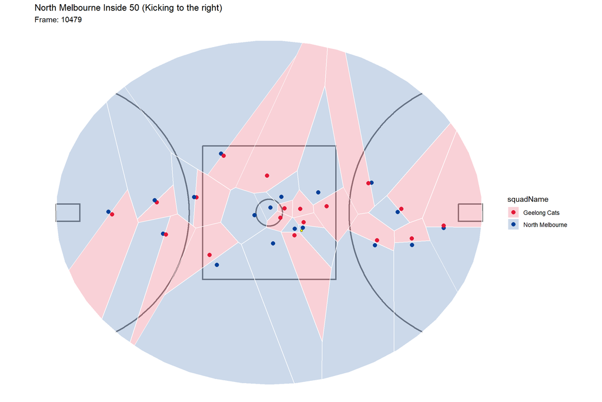

```r
f <- 10479

# Subset ball to segment 1 for the current-position layer
ball_seg <- ball %>%dplyr::filter(frame == f)

ball_seg <- left_join(ball_seg,
                      synced_events %>% select(player_id, squad_name) %>% unique(),
                      by = c("carrier_id" = "player_id"))

ball_seg <- ball_seg %>%
  mutate(squad_name = na_if(squad_name, "NA")) %>%
  fill(squad_name, .direction = "down")

ball_seg <- left_join(ball_seg,
                      tracking %>% select(id, name) %>% unique(),
                      by = c("carrier_id" = "id"))

ball_seg <- ball_seg %>%
  fill(name, .direction = "down")

players <- tracking %>%
 dplyr::filter(status == "ON", is_inside == "ON", frame == f)

squad_cols <- c("North Melbourne" = "#003F98",  # blue
                "Geelong Cats"         = "#E31837")  # red

ggplot() +
  # Ground
  stat_function(fun = function(x) sqrt(5^2 - x^2), xlim = c(-5, 5), geom = "line", alpha = 0.5, colour = "#00000080", linewidth = 1) +
  stat_function(fun = function(x) -sqrt(5^2 - x^2), xlim = c(-5, 5), geom = "line", alpha = 0.5, colour = "#00000080", linewidth = 1) +
  geom_path(data = fa %>% arrange(y), aes(x = x, y = y), alpha = 0.5, colour = "#00000080", linewidth = 1) +
  geom_path(data = fd %>% arrange(y), aes(x = x, y = y), alpha = 0.5, colour = "#00000080", linewidth = 1) +
  geom_rect(aes(xmin = -25, xmax = 25, ymin = -25, ymax = 25), fill = "transparent", colour = "#00000080", linewidth = 1, inherit.aes = FALSE) +
  geom_rect(aes(xmin = 71, xmax = 80, ymin = -3.2, ymax = 3.2), fill = "transparent", colour = "#00000080", linewidth = 1, inherit.aes = FALSE) +
  geom_rect(aes(xmin = -80, xmax = -71, ymin = -3.2, ymax = 3.2), fill = "transparent", colour = "#00000080", linewidth = 1, inherit.aes = FALSE) +
  # Voronoi
  geom_voronoi(data = players, aes(x = x, y = y, fill = squadName), outline = oval[, c("x", "y")], alpha = 0.2, colour = "white") +
  scale_fill_manual(values = squad_cols) +
  # Players
  geom_point(data = players, aes(x=x,y=y,colour = squadName), size = 2.5) +
  scale_colour_manual(values = squad_cols) +
  # Ball
  geom_point(data = ball_seg, aes(x = ball_x, y = ball_y), fill = "yellow", shape = 21, colour = "black", size = 1.5, inherit.aes = FALSE) +
  # Formatting
  theme_void() +
  theme(
    panel.grid.major = element_blank(), # Removes major gridlines
    panel.grid.minor = element_blank()  # Removes minor gridlines
  ) +
  labs(title = "North Melbourne Inside 50 (Kicking to the right)",
       subtitle = paste0("Frame: ", f)) +
  coord_equal()
```

## Static Contested Space Diagram

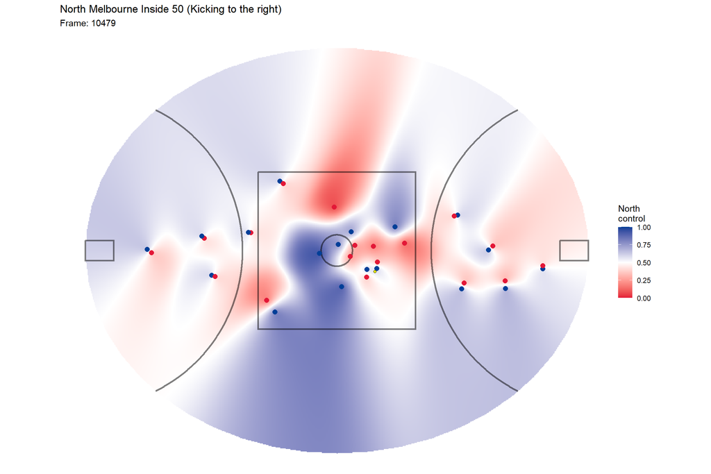

```r
beta  <- 3      # smoothing on time differences (s^-1)
v_max <- 9.6      # m/s common top speed (only beta/v_max matters while static)
res   <- 0.25    # grid resolution (m)

csd_grid <- expand.grid(
  x = seq(-80, 80, by = res),
  y = seq(-64.5, 64.5, by = res)
)
inside <- sp::point.in.polygon(csd_grid$x, csd_grid$y, oval$x, oval$y) > 0
csd_grid <- csd_grid[inside, ]

ref_squad <- "North Melbourne"   # g = this team's control

compute_csd_team <- function(f, grid = csd_grid) {
  players <- tracking %>%
    dplyr::filter(status == "ON", is_inside == "ON", frame == f)

  # n_grid x n_players distance matrix (~ 66k x 36, fine in memory)
  dx <- outer(grid$x, players$x, "-")
  dy <- outer(grid$y, players$y, "-")
  t_arr <- sqrt(dx^2 + dy^2) / v_max

  w <- exp(-beta * t_arr)                       # per-player influence
  is_ref <- players$squadName == ref_squad
  grid$g <- rowSums(w[, is_ref, drop = FALSE]) / rowSums(w)
  grid
}

plot_csd_team <- function(f) {
  g_dat   <- compute_csd_team(f)
  players <- tracking %>%
    dplyr::filter(status == "ON", is_inside == "ON", frame == f)
  ball_seg <- ball %>% dplyr::filter(frame == f)

  ggplot() +
    geom_raster(data = g_dat, aes(x = x, y = y, fill = g)) +
    scale_fill_gradient2(low  = squad_cols["Geelong Cats"],
                         mid  = "white",
                         high = squad_cols["North Melbourne"],
                         midpoint = 0.5, limits = c(0, 1),
                         name = "North\ncontrol") +
    stat_function(fun = function(x)  sqrt(5^2 - x^2), xlim = c(-5, 5),
                  geom = "line", alpha = 0.5, colour = "#00000080", linewidth = 1) +
    stat_function(fun = function(x) -sqrt(5^2 - x^2), xlim = c(-5, 5),
                  geom = "line", alpha = 0.5, colour = "#00000080", linewidth = 1) +
    geom_path(data = fa %>% arrange(y), aes(x = x, y = y),
              alpha = 0.5, colour = "#00000080", linewidth = 1) +
    geom_path(data = fd %>% arrange(y), aes(x = x, y = y),
              alpha = 0.5, colour = "#00000080", linewidth = 1) +
    geom_rect(aes(xmin = -25, xmax = 25, ymin = -25, ymax = 25),
              fill = "transparent", colour = "#00000080", linewidth = 1,
              inherit.aes = FALSE) +
    geom_rect(aes(xmin = 71, xmax = 80, ymin = -3.2, ymax = 3.2),
              fill = "transparent", colour = "#00000080", linewidth = 1,
              inherit.aes = FALSE) +
    geom_rect(aes(xmin = -80, xmax = -71, ymin = -3.2, ymax = 3.2),
              fill = "transparent", colour = "#00000080", linewidth = 1,
              inherit.aes = FALSE) +
    geom_point(data = players, aes(x = x, y = y, colour = squadName), size = 2.5) +
    scale_colour_manual(values = squad_cols, guide = "none") +
    geom_point(data = ball_seg, aes(x = ball_x, y = ball_y),
               fill = "yellow", shape = 21, colour = "black", size = 1.5,
               inherit.aes = FALSE) +
    theme_void() +
    labs(title = "North Melbourne Inside 50 (Kicking to the right)",
         subtitle = paste0("Frame: ", f)) +
    coord_equal()
}

plot_csd_team(10479)
```

## Non-Static Contested Space Diagram

```r
library(signal)
library(zoo)
library(purrr)

fs      <- 25
bf      <- butter(4, 2 / (fs/2), type = "low")  # 2 Hz low-pass on position
max_gap <- 13    # interpolate gaps up to ~0.5 s
min_seg <- 60    # min frames per segment (~2.4 s)
max_spd <- 12.5  # m/s; implied speed above this = tracking jump
edge_n  <- 10    # frames to trim at each segment edge
pad_n   <- 25    # reflection padding for filtfilt (~1 s)
bf_v <- butter(4, 1 / (fs/2), type = "low")   # 1 Hz for the accel pathway

# filtfilt with reflected padding so edge transients land in the padding
safe_filt <- function(z, filt, pad = pad_n) {
  n <- length(z)
  if (n <= pad + 1) return(rep(NA_real_, n))
  z_pad <- c(2 * z[1] - rev(z[2:(pad + 1)]),
             z,
             2 * z[n] - rev(z[(n - pad):(n - 1)]))
  filtfilt(filt, z_pad)[(pad + 1):(pad + n)]
}

process_player <- function(df) {

  df <- df %>%
    arrange(frame) %>%
    mutate(
      suspect = nobs < 3 | status != "ON",
      x_na = if_else(suspect, NA_real_, x),
      y_na = if_else(suspect, NA_real_, y),
      x_i  = na.approx(x_na, maxgap = max_gap, na.rm = FALSE),
      y_i  = na.approx(y_na, maxgap = max_gap, na.rm = FALSE),
      # break segments at NA gaps AND at position jumps
      jump = sqrt((x_i - lag(x_i))^2 + (y_i - lag(y_i))^2) * fs > max_spd,
      seg  = cumsum(is.na(lag(x_i, default = first(x_i))) | coalesce(jump, FALSE))
    ) %>%
   dplyr::filter(!is.na(x_i))

  df %>%
    group_by(seg) %>%
   dplyr::filter(n() >= min_seg) %>%
    mutate(
      x_s = safe_filt(x_i, bf),
      y_s = safe_filt(y_i, bf),
      vx  = c(NA, diff(x_s)) * fs,
      vy  = c(NA, diff(y_s)) * fs,
      speed = sqrt(vx^2 + vy^2),
      dir_v = atan2(vy, vx),
      # second, gentler filter on velocity before differentiating again
      vx_s = safe_filt(coalesce(vx, first(na.omit(vx))), bf_v),
      vy_s = safe_filt(coalesce(vy, first(na.omit(vy))), bf_v),
      ax  = c(NA, diff(vx_s)) * fs,
      ay  = c(NA, diff(vy_s)) * fs,
      a_tang = ax * cos(dir_v) + ay * sin(dir_v),
      a_norm = -ax * sin(dir_v) + ay * cos(dir_v),
      # belt-and-braces edge trim
      edge = row_number() <= edge_n | row_number() > n() - edge_n,
      across(c(vx, vy, speed, dir_v, ax, ay, a_tang, a_norm),
             ~ if_else(edge, NA_real_, .x)),
      dir_v = if_else(speed < 0.5, NA_real_, dir_v)
    ) %>%
    ungroup() %>%
    select(-x_na, -y_na, -jump, -edge)
}

tracking_out <- tracking %>%
  group_split(id) %>%
  map(process_player) %>%
  list_rbind()

tracking_out <- tracking_out %>%
  mutate(across(c(ax, ay, a_tang, a_norm),
                ~ if_else(abs(a_tang) > 10, NA_real_, .x)))
```

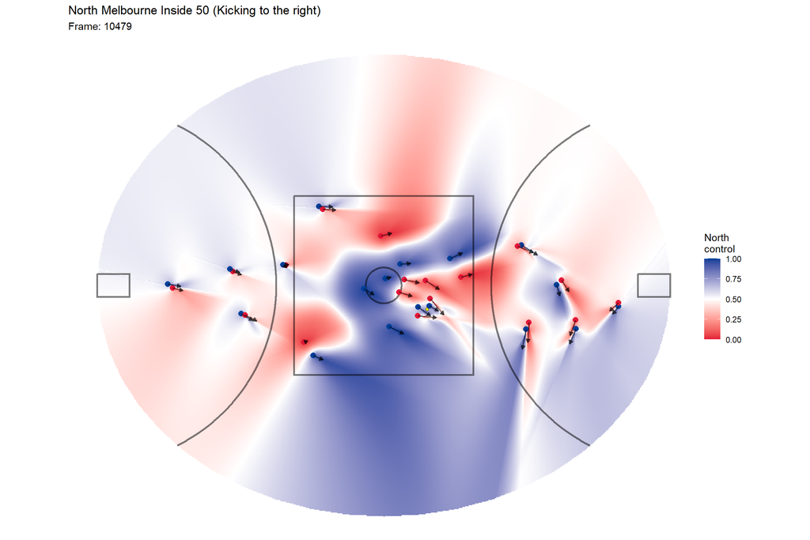

```r
yd <- 0.9144
phys <- list(
  astop = 12   * yd,   # braking capability  (m/s^2)
  ago   = 8    * yd,   # acceleration        (m/s^2)
  aturn = 7    * yd,   # max centripetal acc (m/s^2)
  vmax  = 10.5 * yd    # top speed ~9.6 m/s
)

beta <- 3   # paper uses beta = 1 for the field softmax (not 5)

# time to cover distance d in a straight line, entering at speed vi,
# accelerating at a, capped (approximately, as in the paper) at vmax
straight_line_time <- function(d, vi, a, vmax) {
  d <- pmax(d, 0)
  s <- sqrt(vi^2 + 2 * a * d)
  (s - vi) / a + pmax(0, s - vmax)^2 / (2 * a * vmax)
}

# arrival time from one player to every grid point (vectorised over grid)
player_arrival_time <- function(gx, gy, px, py, vi, vt,
                                p = phys, n_vturn = 20) {
  x <- gx - px
  y <- gy - py

  # no reliable velocity (segment edges, speed < 0.5 -> dir_v NA, or standing):
  # accelerate from rest -- this is also the better "static" model
  if (is.na(vi) || is.na(vt) || vi < 0.5) {
    return(straight_line_time(sqrt(x^2 + y^2), 0, p$ago, p$vmax))
  }

  # rotate so velocity points along +y; reflect so target x <= 0 (CCW turn)
  ang <- pi / 2 - vt
  xr  <- x * cos(ang) - y * sin(ang)
  yr  <- x * sin(ang) + y * cos(ang)
  xr  <- -abs(xr)

  vturns <- unique(c(seq(0.15, p$vmax, length.out = n_vturn), vi))

  best <- rep(Inf, length(xr))
  for (vturn in vturns) {
    r <- vturn^2 / p$aturn
    if (vturn > vi) {
      t1 <- (vturn - vi) / p$ago;   y1 <- vi * t1 + 0.5 * p$ago   * t1^2
    } else if (vturn < vi) {
      t1 <- (vi - vturn) / p$astop; y1 <- vi * t1 - 0.5 * p$astop * t1^2
    } else { t1 <- 0; y1 <- 0 }

    y2   <- yr - y1
    disc <- xr^2 + 2 * r * xr + y2^2      # < 0 => target inside turning circle
    ok   <- disc >= 0
    phi  <- (2 * atan2(-xr, y2 + sqrt(pmax(disc, 0)))) %% (2 * pi)
    t2   <- r * phi / vturn
    dnew <- sqrt((xr - r * (1 - cos(phi)))^2 + (y2 + r * sin(phi))^2)

    tt <- t1 + t2 + straight_line_time(dnew, vturn, p$ago, p$vmax)
    tt[!ok] <- Inf
    best <- pmin(best, tt)
  }

  # special cases as in the paper: target ~straight ahead or straight behind
  thr    <- 0.1
  ahead  <- abs(xr) <= thr & yr >= 0
  behind <- abs(xr) <= thr & yr < 0
  if (any(ahead))
    best[ahead] <- straight_line_time(yr[ahead], vi, p$ago, p$vmax)
  if (any(behind)) {
    t1 <- vi / p$astop
    y1 <- vi^2 / (2 * p$astop)
    best[behind] <- t1 + straight_line_time(-yr[behind] + y1, 0, p$ago, p$vmax)
  }
  best
}

# --- team CSD: softmax over exp(-beta * t) grouped by squad ------------------
# NOTE: uses tracking_out (needs speed + dir_v from your Butterworth pipeline)
compute_csd_phys <- function(f, grid = csd_grid) {
  players <- tracking_out %>%
    dplyr::filter(status == "ON", is_inside == "ON", frame == f)

  Tmat <- vapply(
    seq_len(nrow(players)),
    function(i) player_arrival_time(grid$x, grid$y,
                                    players$x[i],     players$y[i],
                                    players$speed[i], players$dir_v[i]),
    numeric(nrow(grid))
  )

  w <- exp(-beta * Tmat)
  is_ref <- players$squadName == ref_squad
  grid$g <- rowSums(w[, is_ref, drop = FALSE]) / rowSums(w)
  grid
}

plot_csd_phys <- function(f) {
  g_dat   <- compute_csd_phys(f)
  players <- tracking_out %>%
    dplyr::filter(status == "ON", is_inside == "ON", frame == f)
  ball_seg <- ball %>% dplyr::filter(frame == f)

  ggplot() +
    geom_raster(data = g_dat, aes(x = x, y = y, fill = g)) +
    scale_fill_gradient2(low  = squad_cols["Geelong Cats"],
                         mid  = "white",
                         high = squad_cols["North Melbourne"],
                         midpoint = 0.5, limits = c(0, 1),
                         name = "North\ncontrol") +
    stat_function(fun = function(x)  sqrt(5^2 - x^2), xlim = c(-5, 5),
                  geom = "line", alpha = 0.5, colour = "#00000080", linewidth = 1) +
    stat_function(fun = function(x) -sqrt(5^2 - x^2), xlim = c(-5, 5),
                  geom = "line", alpha = 0.5, colour = "#00000080", linewidth = 1) +
    geom_path(data = fa %>% arrange(y), aes(x = x, y = y),
              alpha = 0.5, colour = "#00000080", linewidth = 1) +
    geom_path(data = fd %>% arrange(y), aes(x = x, y = y),
              alpha = 0.5, colour = "#00000080", linewidth = 1) +
    geom_rect(aes(xmin = -25, xmax = 25, ymin = -25, ymax = 25),
              fill = "transparent", colour = "#00000080", linewidth = 1,
              inherit.aes = FALSE) +
    geom_rect(aes(xmin = 71, xmax = 80, ymin = -3.2, ymax = 3.2),
              fill = "transparent", colour = "#00000080", linewidth = 1,
              inherit.aes = FALSE) +
    geom_rect(aes(xmin = -80, xmax = -71, ymin = -3.2, ymax = 3.2),
              fill = "transparent", colour = "#00000080", linewidth = 1,
              inherit.aes = FALSE) +
    geom_point(data = players, aes(x = x, y = y, colour = squadName),
               size = 2.5) +
    # velocity arrows (same style as your vector plot)
    geom_segment(data = players %>% dplyr::filter(!is.na(vx)),
                 aes(x = x, y = y, xend = x + vx * 0.8, yend = y + vy * 0.8),
                 arrow = arrow(length = unit(0.15, "cm"), type = "closed"),
                 linewidth = 0.6, colour = "black", alpha = 0.5,
                 inherit.aes = FALSE) +
    scale_colour_manual(values = squad_cols, guide = "none") +
    geom_point(data = ball_seg, aes(x = ball_x, y = ball_y),
               fill = "yellow", shape = 21, colour = "black", size = 1.5,
               inherit.aes = FALSE) +
    theme_void() +
    labs(title = "North Melbourne Inside 50 (Kicking to the right)",
         subtitle = paste0("Frame: ", f)) +
    coord_equal()
}

plot_csd_phys(10479)
```

## Individual Player Physical Abilities

```r
player_phys <- tracking_out %>%
  group_by(id, name) %>%
  summarise(
    vmax  = quantile(speed, 0.99995, na.rm = TRUE),
    ago   = quantile(a_tang[speed < 4], 0.99995, na.rm = TRUE),  # accel from low speed
    astop = -quantile(a_tang, 0.00005, na.rm = TRUE),            # hardest braking
    aturn = quantile(abs(a_norm), 0.99995, na.rm = TRUE),
    n     = sum(!is.na(speed))
  )

player_phys %>% arrange(desc(vmax)) %>% head(10)
```

```
# A tibble: 10 × 7
# Groups:   id [10]
        id name                 vmax   ago astop aturn     n
     <int> <chr>               <dbl> <dbl> <dbl> <dbl> <int>
 1  291357 Gary Rohan           9.87  7.19  9.69  8.64 40354
 2 1006152 Jordan Clark         9.84  6.01  8.56  7.67 40096
 3  297767 Sam Durdin           9.20  6.25  9.64  6.51 38191
 4  992499 Kayne Turner         9.00  6.69  9.21  8.51 29122
 5  993998 Jy Simpkin           8.99  6.08  6.48  8.16 27068
 6  998484 Cameron Zurhaar      8.88  6.72  9.29  7.84 36787
 7  291526 Luke Dahlhaus        8.62  7.62  7.70  9.70 36397
 8  290787 Shaun Atley          8.62  8.00  8.93  9.65 38368
 9  280944 Jack Ziebell         8.61  7.36  6.73 10.5  39750
10  270917 Patrick Dangerfield  8.58  5.68  7.92  7.78 39166
```

```r
player_phys %>% arrange(vmax) %>% head(10)
```

```
# A tibble: 10 × 7
# Groups:   id [10]
        id name               vmax   ago astop aturn     n
     <int> <chr>             <dbl> <dbl> <dbl> <dbl> <int>
 1  280921 Ben Cunnington     6.00  7.39  5.69  7.72 32446
 2 1002220 Esava Ratugolea    6.58  7.51  6.76  9.06 24725
 3 1002242 Charlie Constable  6.88  7.42  9.14  8.69 33999
 4  261510 Tom Hawkins        7.02  6.20  5.60  7.69 43406
 5 1007102 Mark O'Connor      7.09  7.09  6.70  7.40 37935
 6  291861 Jed Anderson       7.12  7.75  8.86 10.2  37938
 7  296291 Jake Kolodjashnij  7.17  7.09  8.44  6.88 42463
 8 1001017 Nick Larkey        7.22  7.45  8.26  8.06 39991
 9  295898 Tim Kelly          7.30  7.59  7.72 10.1  37712
10  298419 Brandan Parfitt    7.31  6.99  7.95  8.03 32300
```

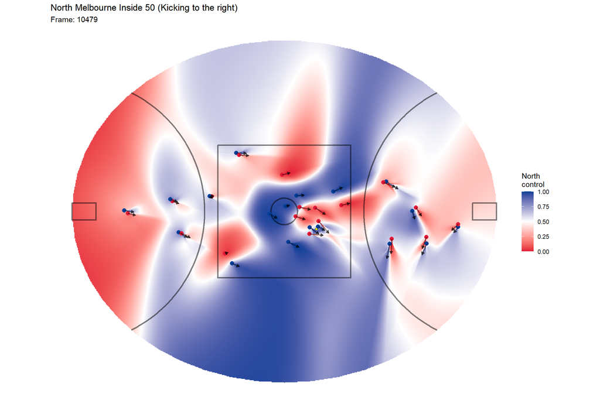

```r
#### Updated function

compute_csd_phys <- function(f, grid = csd_grid) {
  players <- tracking_out %>%
    dplyr::filter(status == "ON", is_inside == "ON", frame == f) %>%
    left_join(player_phys, by = "id") %>%
    mutate(
      # fall back to global params if a player has no estimate,
      # and floor vmax at their current speed
      vmax  = coalesce(vmax,  phys$vmax),
      ago   = coalesce(ago,   phys$ago),
      astop = coalesce(astop, phys$astop),
      aturn = coalesce(aturn, phys$aturn),
      vmax  = pmax(vmax, speed + 0.5, na.rm = TRUE)
    )

  Tmat <- vapply(
    seq_len(nrow(players)),
    function(i) {
      p_i <- list(vmax  = players$vmax[i],  ago   = players$ago[i],
                  astop = players$astop[i], aturn = players$aturn[i])
      player_arrival_time(grid$x, grid$y,
                          players$x[i],     players$y[i],
                          players$speed[i], players$dir_v[i],
                          p = p_i)
    },
    numeric(nrow(grid))
  )

  w <- exp(-beta * Tmat)
  is_ref <- players$squadName == ref_squad
  grid$g <- rowSums(w[, is_ref, drop = FALSE]) / rowSums(w)
  grid
}

plot_csd_phys(10479)
```

Players to the far left - Gary Rohan (Geelong) and Jamie Macmillan (North)

### Another method - Used in [ExpPasses](https://www.researchgate.net/publication/357576300_Expected_passes) Paper

Would require a lot more data. Transforms each frame position to the origin and velcoity to be moving to the right and records where the player ended up after x frames (25/1 second used here) for binned starting velocities Convex hull of all possible locations (paper says convex hull but actually shows circles encompassing all points in Fig 3) Bin width could be reduced with additional data (paper used 0.5km/h or ~0.14m/s)

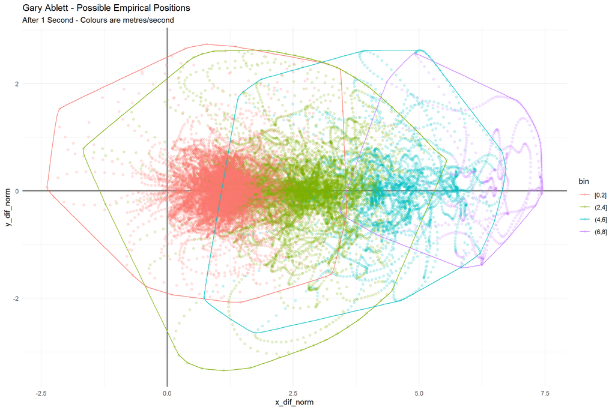

```r
gaz <- tracking_out %>% drop_na(speed) %>% dplyr::filter(id == 220001) %>% select(frame, x, y, speed, dir_v)

# 1. Create a reference dataframe with just the lookup columns
gaz_lookup <- gaz %>%
  select(frame, x_lead25 = x, y_lead25 = y)

# 2. Join the data based on the target future frame
gaz_lagged <- gaz %>%
  mutate(target_frame = frame + 25) %>%
  left_join(gaz_lookup, by = c("target_frame" = "frame")) %>%
  select(-target_frame) # Optional: removes the temporary helper column

gaz_lagged <- gaz_lagged %>%
  mutate(x_dif = x_lead25 - x,
         y_dif = y_lead25 - y)

gaz_normalised <- gaz_lagged %>%
  mutate(
    # Rotate the differences by -dir_v
    x_dif_norm = x_dif * cos(dir_v) + y_dif * sin(dir_v),
    y_dif_norm = -x_dif * sin(dir_v) + y_dif * cos(dir_v),
    bin = cut_width(speed, width = 2, boundary = 0)
  )

library(ggalt)

gaz_normalised %>%
  dplyr::filter(!is.na(x_dif_norm)) %>%
  # Move 'fill = bin' out of the global ggplot() aes if you don't want it anywhere
  ggplot(aes(x = x_dif_norm, y = y_dif_norm, colour = bin)) +
  geom_hline(yintercept = 0) +
  geom_vline(xintercept = 0) +
  geom_point(alpha = 0.2) +
  geom_encircle(fill = NA, alpha = 1, s_shape=0.9, expand = 0) +
  theme_minimal() +
  labs(title = "Gary Ablett - Possible Empirical Positions",
       subtitle = "After 1 Second - Colours are metres/second")
```

## Application

I’m very happy with the outcome and think they are already very useful to visually understand who owns space. The big issue is that it’s compute intensive to calculate the state of each 0.25m square 25 times a second in R and making GIFs of the 14 inside 50s for the quarter took around 14 hours using all 28 of the cores on my decent desktop cpu.

To solve this I got Claude Code to help convert my R prototype into a web shader in Javascript and now it can solve at the same resolution while playing the video at 4x speed. The output is also within 0.01% of the original R version.

See below an example of the application. You can select any of the inside 50s for the quarter or just watch the whole thing.

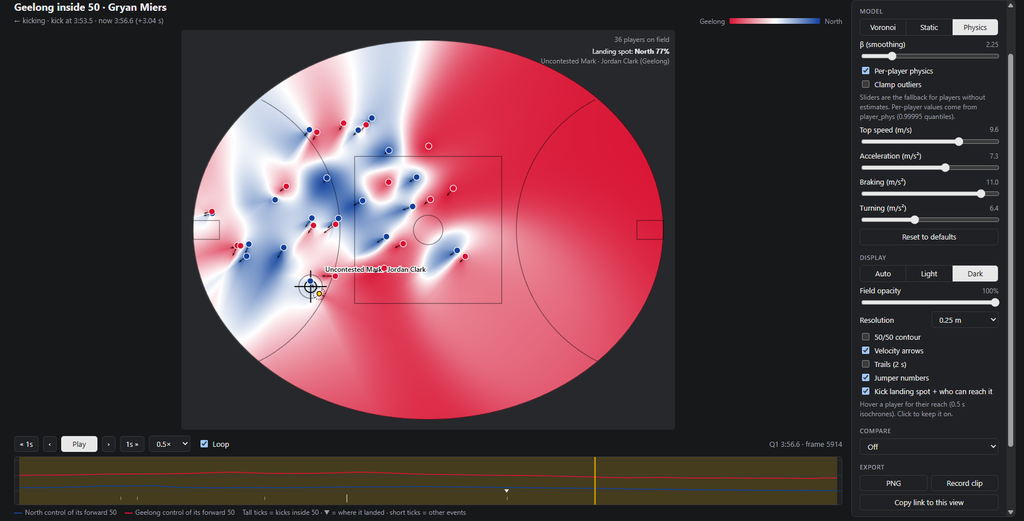

Application

I’ve also added an option to clip video of specific events with an example at 0.5 times speed below. There is no real reason not to just use the application (it also includes useful hover effects and the ability to jump to the kick/mark etc) other than not wanting to share the data.

[video not shown]

## Other ideas/applications

### Kicking simulations

- One metric of how easy a kick is could be to simulate possible kick trajectories given the speed/heading of the player with the ball
  - Logically, the faster you are running the more liekly you are to kick in the direction you’re heading
- Test every kick to see if a teammate can get to the drop first for an uncontested
  - Or a 1v1 to advantage - Understanding body work will be an interesting side project but would most likely require more data that is more accurate

```r
# AFL drop punt grid search, plotted in 3D over the field
# Field coords match your ggplot setup: 160 x 129 oval centred at (0,0),
# goals on the x axis at x = +/-80. install.packages(c("deSolve","plotly")) if needed.

library(deSolve)
library(plotly)

# ---- Physics (unchanged) ----------------------------------------------------
params <- list(m = 0.48, Cd = 0.40, A = 0.035, rho = 1.225, g = 9.81)

deriv <- function(t, state, p) {
  with(as.list(c(state, p)), {
    v <- sqrt(vx^2 + vy^2 + vz^2)
    k <- 0.5 * rho * Cd * A / m
    list(c(vx, vy, vz, -k * v * vx, -k * v * vy, -k * v * vz - g))
  })
}
root_fn <- function(t, state, p) state["z"]

# Kick from field position (x0, y0), facing `bearing_deg`
# (0 = towards +x goal, 180 = towards -x goal, i.e. "kicking to the left").
# Azimuth is relative to that bearing (+ = to the kicker's left in field coords).
kick_flight <- function(speed, azimuth_deg, elevation_deg,
                        x0 = 0, y0 = 0, bearing_deg = 0,
                        p = params, z0 = 0.3, dt = 0.02) {
  dir <- (bearing_deg + azimuth_deg) * pi / 180
  el  <- elevation_deg * pi / 180
  state <- c(x = x0, y = y0, z = z0,
             vx = speed * cos(el) * cos(dir),
             vy = speed * cos(el) * sin(dir),
             vz = speed * sin(el))
  as.data.frame(ode(y = state, times = seq(0, 15, by = dt), func = deriv,
                    parms = p, rootfun = root_fn, method = "lsodar"))
}

# ---- Grid search ------------------------------------------------------------
grid_search <- function(speeds, azimuths, elevations,
                        x0 = 0, y0 = 0, bearing_deg = 0, p = params) {
  grid <- expand.grid(speed = speeds, azimuth = azimuths, elevation = elevations)
  n <- nrow(grid); message(n, " kicks to simulate")
  traj_list <- vector("list", n)
  grid$distance <- grid$lateral <- grid$max_height <- grid$hang_time <- NA_real_

  for (i in seq_len(n)) {
    tr <- kick_flight(grid$speed[i], grid$azimuth[i], grid$elevation[i],
                      x0 = x0, y0 = y0, bearing_deg = bearing_deg, p = p)
    tr$kick_id <- i
    tr$label <- sprintf("v=%.0f m/s, az=%.0f\u00b0, el=%.0f\u00b0",
                        grid$speed[i], grid$azimuth[i], grid$elevation[i])
    traj_list[[i]] <- tr
    dx <- tail(tr$x, 1) - x0; dy <- tail(tr$y, 1) - y0
    grid$distance[i]   <- sqrt(dx^2 + dy^2)
    grid$lateral[i]    <- dy
    grid$max_height[i] <- max(tr$z)
    grid$hang_time[i]  <- tail(tr$time, 1)
  }
  list(summary = grid, trajectories = do.call(rbind, traj_list))
}

# ---- Field line data (matches your ggplot field) ----------------------------
field_lines <- function() {
  ang  <- seq(-pi, pi, length.out = 200)
  oval <- data.frame(x = 80 * sin(ang), y = 64.5 * cos(ang))          # 160 x 129

  y50  <- seq(-44.7, 44.7, by = 0.1)                                   # 50m arcs
  arc_r <- data.frame(x =  -(sqrt(50^2 - y50^2) - 80), y = y50)        # right goal
  arc_l <- data.frame(x =   (sqrt(50^2 - y50^2) - 80), y = y50)        # left goal

  sq <- function(x1, x2, y1, y2)
    data.frame(x = c(x1, x2, x2, x1, x1), y = c(y1, y1, y2, y2, y1))
  centre_sq <- sq(-25, 25, -25, 25)
  goal_r    <- sq(71, 80, -3.2, 3.2)
  goal_l    <- sq(-80, -71, -3.2, 3.2)
  circ      <- data.frame(x = 5 * cos(ang), y = 5 * sin(ang))          # centre circle

  list(oval = oval, arc_r = arc_r, arc_l = arc_l,
       centre_sq = centre_sq, goal_r = goal_r, goal_l = goal_l, circ = circ)
}

# Goal posts as vertical 3D lines (goals 6.4m wide, behinds 6.4m out, posts ~6m/3m)
goal_posts <- function() {
  posts <- rbind(
    expand.grid(x = c(-80, 80), y = c(-3.2, 3.2), h = 6),   # goal posts
    expand.grid(x = c(-80, 80), y = c(-9.6, 9.6), h = 3)    # behind posts
  )
  posts
}

# ---- 3D plot: field at z = 0, trajectories above ----------------------------
plot_kicks_field <- function(res) {
  fl <- field_lines()
  tr <- merge(res$trajectories,
              transform(res$summary, kick_id = seq_len(nrow(res$summary)))[,
                                                                           c("kick_id", "distance")], by = "kick_id")

  fig <- plot_ly()

  # grass surface (flat oval-ish rectangle kept subtle)
  fig <- fig |> add_trace(
    x = fl$oval$x, y = fl$oval$y, z = rep(0, nrow(fl$oval)),
    type = "scatter3d", mode = "lines",
    line = list(color = "white", width = 5),
    hoverinfo = "none", showlegend = FALSE)

  for (nm in c("arc_r", "arc_l", "centre_sq", "goal_r", "goal_l", "circ")) {
    d <- fl[[nm]]
    fig <- fig |> add_trace(
      x = d$x, y = d$y, z = rep(0, nrow(d)),
      type = "scatter3d", mode = "lines",
      line = list(color = "white", width = 4),
      hoverinfo = "none", showlegend = FALSE)
  }

  # goal / behind posts
  gp <- goal_posts()
  for (i in seq_len(nrow(gp))) {
    fig <- fig |> add_trace(
      x = rep(gp$x[i], 2), y = rep(gp$y[i], 2), z = c(0, gp$h[i]),
      type = "scatter3d", mode = "lines",
      line = list(color = "#F2F2F2", width = 6),
      hoverinfo = "none", showlegend = FALSE)
  }

  # trajectories, coloured by distance
  fig <- fig |> add_trace(
    data = tr, x = ~x, y = ~y, z = ~z, split = ~kick_id,
    color = ~distance, colors = "viridis",
    type = "scatter3d", mode = "lines",
    line = list(width = 4),
    text = ~label, hoverinfo = "text", showlegend = FALSE)

  fig |> layout(
    paper_bgcolor = "#DFF0D8",
    scene = list(
      xaxis = list(title = "", range = c(-85, 85), showgrid = FALSE,
                   zeroline = FALSE, showticklabels = FALSE,
                   backgroundcolor = "#4DBD33", showbackground = FALSE),
      yaxis = list(title = "", range = c(-68, 68), showgrid = FALSE,
                   zeroline = FALSE, showticklabels = FALSE),
      zaxis = list(title = "Height (m)", range = c(0, 30)),
      aspectmode = "data",
      camera = list(eye = list(x = 0, y = -1.6, z = 0.9))
    ))
}

# ---- Example: kicking to the left goal from centre half-forward -------------
res <- grid_search(
  speeds     = seq(16, 40, by = 8),
  azimuths   = seq(-45, 45, by = 4),
  elevations = seq(20, 60, by = 20),
  x0 = 12.15, y0 = -6.76, bearing_deg = -28      # 50m out, kicking towards x = -80
)

head(res$summary)
```

```
  speed azimuth elevation hang_time max_height   lateral distance
1    16     -45        20  1.120297   1.688630 -14.04129 14.68286
2    24     -45        20  1.557195   3.130912 -25.92848 27.11320
3    32     -45        20  1.936426   4.790597 -37.86814 39.59840
4    40     -45        20  2.260030   6.523817 -48.91041 51.14521
5    16     -41        20  1.120297   1.688630 -13.70763 14.68286
6    24     -41        20  1.557195   3.130912 -25.31235 27.11320
```

```r
plot_kicks_field(res)
```

[interactive chart not shown]